# Análisis de Expresión Génica

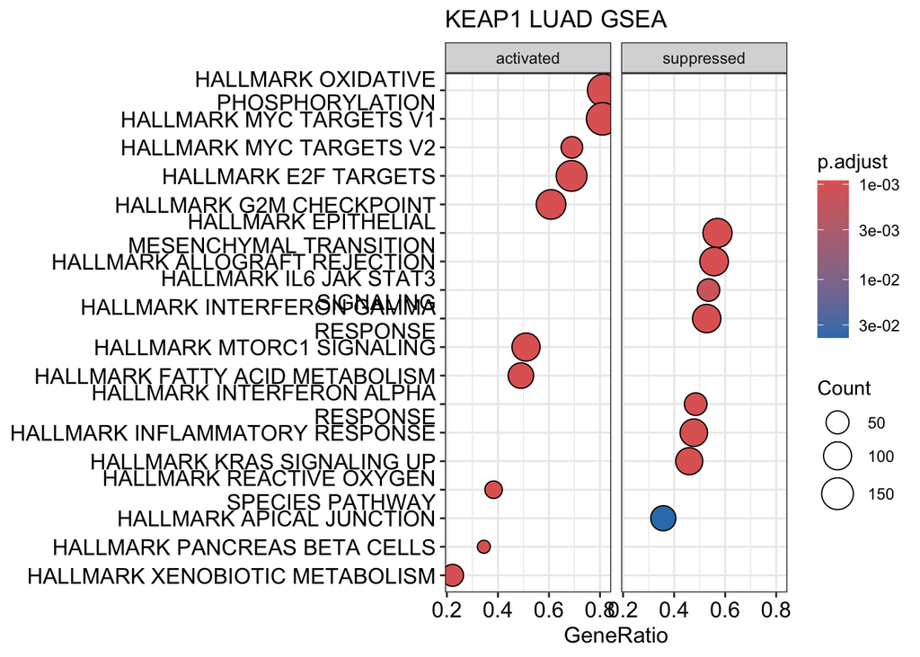

```r
################
# KEAP1
################
set.seed(1234)
res_KEAP1 <- run_edger_deg(
  expr_mat = LUAD_mat_driv,
  meta = luad_meta_driv,
  status_col = "KEAP1_status"
)

gene_list_KEAP1 <- res_KEAP1$logFC
names(gene_list_KEAP1) <- res_KEAP1$SYMBOL
gene_list_KEAP1<- sort(gene_list_KEAP1, decreasing = TRUE)

msig_res_hall_KEAP1 <- GSEA(geneList = gene_list_KEAP1,
                 TERM2GENE = m_hall_symbol,
                 pvalueCutoff = 0.05,
                 minGSSize = 10,
                 maxGSSize = 500,
                 nPerm = 10000,
                 pAdjustMethod = "BH")



dotplot(msig_res_hall_KEAP1, split = ".sign",title="KEAP1 LUAD GSEA") +
  facet_grid(. ~ .sign)
```

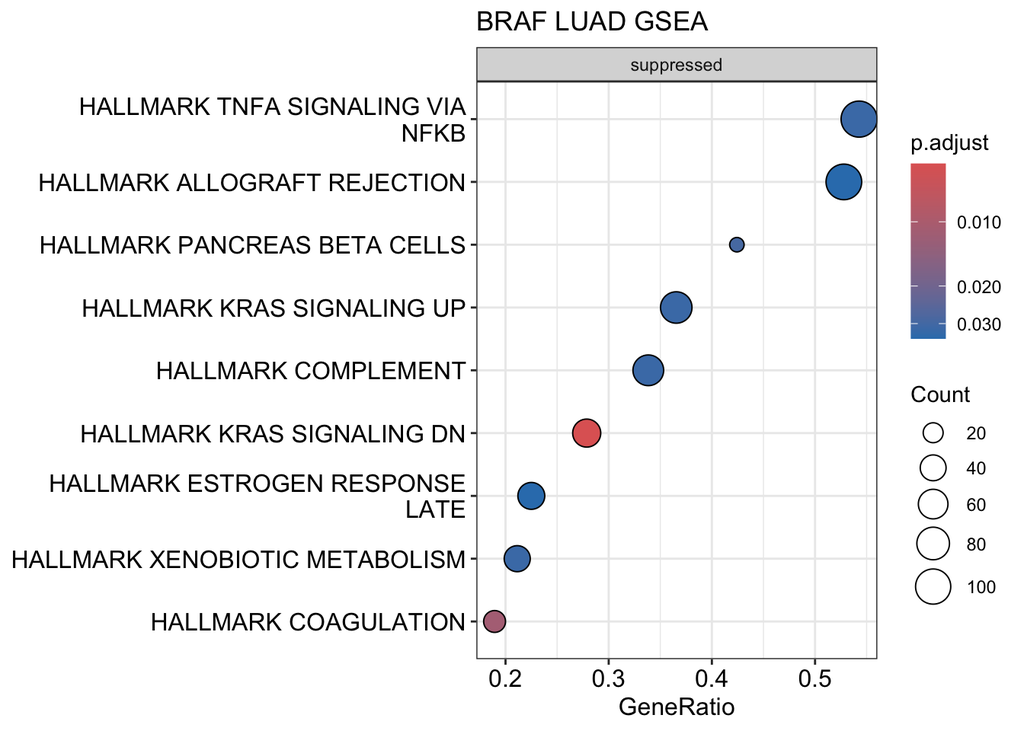

```r
################
# BRAF
################
set.seed(1234)
res_BRAF <- run_edger_deg(
  expr_mat = LUAD_mat_driv,
  meta = luad_meta_driv,
  status_col = "BRAF_status"
)

gene_list_BRAF <- res_BRAF$logFC
names(gene_list_BRAF) <- res_BRAF$SYMBOL
gene_list_BRAF<- sort(gene_list_BRAF, decreasing = TRUE)

msig_res_hall_BRAF <- GSEA(geneList = gene_list_BRAF,
                 TERM2GENE = m_hall_symbol,
                 pvalueCutoff = 0.05,
                 minGSSize = 10,
                 maxGSSize = 500,
                 nPerm = 10000,
                 pAdjustMethod = "BH")



dotplot(msig_res_hall_BRAF, split = ".sign",title="BRAF LUAD GSEA") +
  facet_grid(. ~ .sign)
```

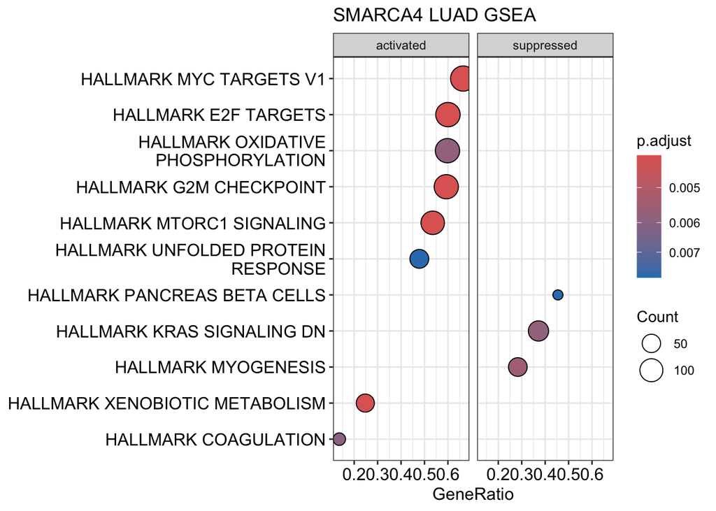

```r
################
# SMARCA4
################
set.seed(1234)
res_SMARCA4 <- run_edger_deg(
  expr_mat = LUAD_mat_driv,
  meta = luad_meta_driv,
  status_col = "SMARCA4_status"
)

gene_list_SMARCA4 <- res_SMARCA4$logFC
names(gene_list_SMARCA4) <- res_SMARCA4$SYMBOL
gene_list_SMARCA4<- sort(gene_list_SMARCA4, decreasing = TRUE)

msig_res_hall_SMARCA4 <- GSEA(geneList = gene_list_SMARCA4,
                 TERM2GENE = m_hall_symbol,
                 pvalueCutoff = 0.05,
                 minGSSize = 10,
                 maxGSSize = 500,
                 nPerm = 10000,
                 pAdjustMethod = "BH")



dotplot(msig_res_hall_SMARCA4, split = ".sign",title="SMARCA4 LUAD GSEA") +
  facet_grid(. ~ .sign)
```

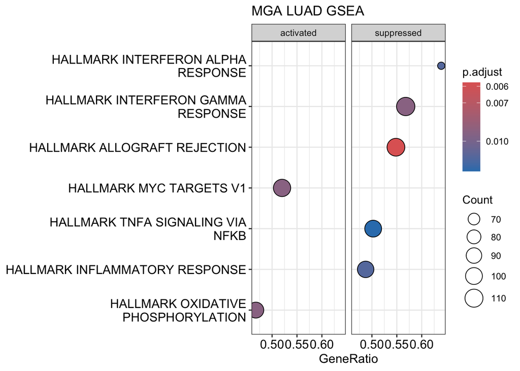

```r
################
# MGA
################
set.seed(1234)
res_MGA <- run_edger_deg(
  expr_mat = LUAD_mat_driv,
  meta = luad_meta_driv,
  status_col = "MGA_status"
)

gene_list_MGA <- res_MGA$logFC
names(gene_list_MGA) <- res_MGA$SYMBOL
gene_list_MGA<- sort(gene_list_MGA, decreasing = TRUE)


msig_res_hall_MGA <- GSEA(geneList = gene_list_MGA,
                 TERM2GENE = m_hall_symbol,
                 pvalueCutoff = 0.05,
                 minGSSize = 10,
                 maxGSSize = 500,
                 nPerm = 10000,
                 pAdjustMethod = "BH")



dotplot(msig_res_hall_MGA, split = ".sign",title="MGA LUAD GSEA") +
  facet_grid(. ~ .sign)
```

### 9.3.3. EdgeR genes driver (mut vs wt) y GSEA Hallmarc LUSC:

Del estudio ha quedado a fuera el gen NFE2L2, por ausencia de pathways enriquecidas. Se ha seguido el fljo de trabajo que se ha descrito anteriormente con LUAD, tanto la preparacón de las muestras como el uso de EdgeR y Hallmarc, la unica distinción es que se han usado genes drivers especificos de LUSC.

```r
#########################################################
# PREPARACIÓN DATOS LUSC
#########################################################

lusc_mut_wt$barcode_short <- substr(lusc_mut_wt$Tumor_Sample_Barcode, 1, 16)
colnames(LUSC_mat) <- substr(colnames(LUSC_mat), 1, 16)

common_samples <- intersect(colnames(LUSC_mat), lusc_mut_wt$barcode_short)

length(common_samples)
```

```
## [1] 477
```

```r
LUSC_mat_driv <- LUSC_mat[, common_samples, drop = FALSE]

lusc_meta_driv <- lusc_mut_wt[
  lusc_mut_wt$barcode_short %in% common_samples,
]

lusc_meta_driv <- lusc_meta_driv[
  match(common_samples, lusc_meta_driv$barcode_short),
]

LUSC_mat_driv <- LUSC_mat_driv[, lusc_meta_driv$barcode_short]

table(lusc_meta_driv$TP53_status)
```

```
##
## MUT  WT
## 399  78
```

```r
table(lusc_meta_driv$NFE2L2_status)
```

```
##
## MUT  WT
##  71 406
```

```r
table(lusc_meta_driv$KMT2D_status)
```

```
##
## MUT  WT
## 106 371
```

```r
table(lusc_meta_driv$PTEN_status)
```

```
##
## MUT  WT
##  51 426
```

```r
table(lusc_meta_driv$CDKN2A_status)
```

```
##
## MUT  WT
##  71 406
```

```r
table(lusc_meta_driv$PIK3CA_status)
```

```
##
## MUT  WT
##  56 421
```

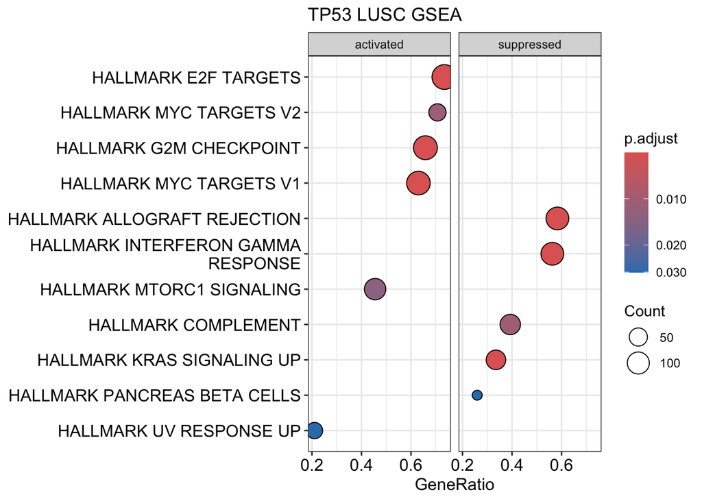

```r
#########################################################
# TP53
#########################################################

set.seed(1234)

res_TP53 <- run_edger_deg(
  expr_mat = LUSC_mat_driv,
  meta = lusc_meta_driv,
  status_col = "TP53_status"
)

gene_list_TP53 <- res_TP53$logFC

names(gene_list_TP53) <- res_TP53$SYMBOL

gene_list_TP53 <- sort(gene_list_TP53, decreasing = TRUE)

msig_res_hall_TP53 <- GSEA(
  geneList = gene_list_TP53,
  TERM2GENE = m_hall_symbol,
  pvalueCutoff = 0.05,
  minGSSize = 10,
  maxGSSize = 500,
  nPerm = 10000,
  pAdjustMethod = "BH"
)

dotplot(
  msig_res_hall_TP53,
  split = ".sign",
  title = "TP53 LUSC GSEA"
) +
  facet_grid(. ~ .sign)
```

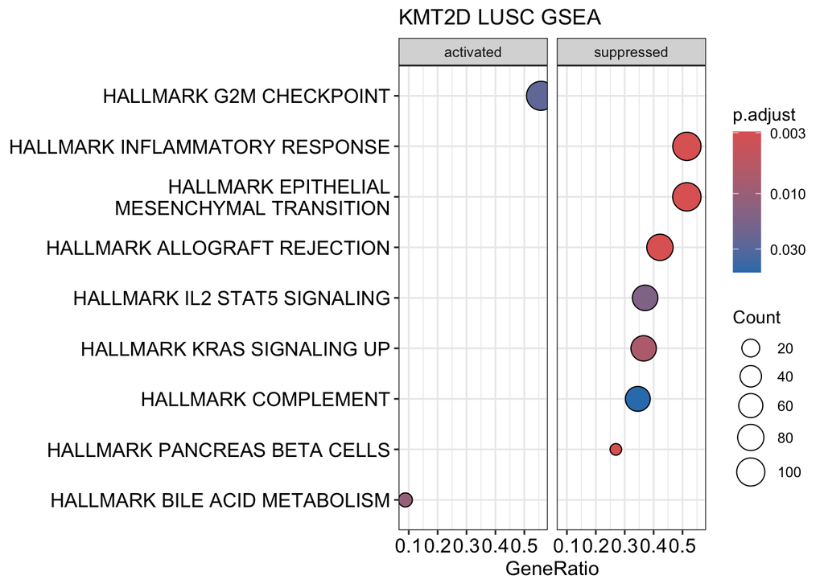

```r
#No hay NFE2L2 porque no hay vias asociadas
#########################################################
# KMT2D
#########################################################

set.seed(1234)

res_KMT2D <- run_edger_deg(
  expr_mat = LUSC_mat_driv,
  meta = lusc_meta_driv,
  status_col = "KMT2D_status"
)

gene_list_KMT2D <- res_KMT2D$logFC

names(gene_list_KMT2D) <- res_KMT2D$SYMBOL

gene_list_KMT2D <- sort(gene_list_KMT2D, decreasing = TRUE)

msig_res_hall_KMT2D <- GSEA(
  geneList = gene_list_KMT2D,
  TERM2GENE = m_hall_symbol,
  pvalueCutoff = 0.05,
  minGSSize = 10,
  maxGSSize = 500,
  nPerm = 10000,
  pAdjustMethod = "BH"
)

dotplot(
  msig_res_hall_KMT2D,
  split = ".sign",
  title = "KMT2D LUSC GSEA"
) +
  facet_grid(. ~ .sign)
```

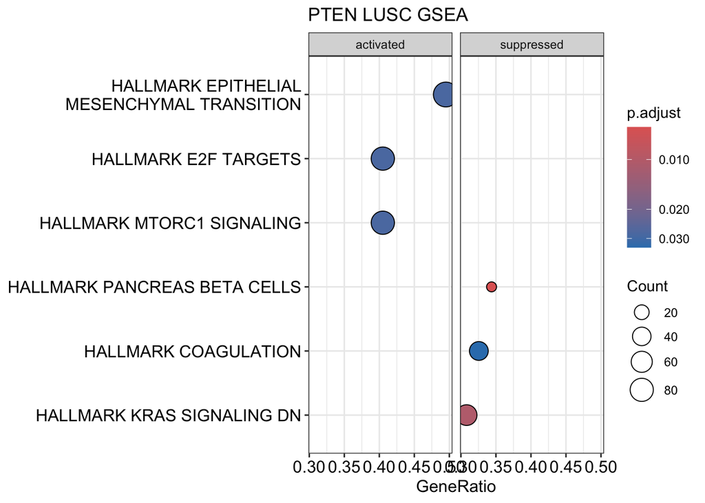

```r
#########################################################
# PTEN
#########################################################

set.seed(1234)

res_PTEN <- run_edger_deg(
  expr_mat = LUSC_mat_driv,
  meta = lusc_meta_driv,
  status_col = "PTEN_status"
)

gene_list_PTEN <- res_PTEN$logFC

names(gene_list_PTEN) <- res_PTEN$SYMBOL

gene_list_PTEN <- sort(gene_list_PTEN, decreasing = TRUE)

msig_res_hall_PTEN <- GSEA(
  geneList = gene_list_PTEN,
  TERM2GENE = m_hall_symbol,
  pvalueCutoff = 0.05,
  minGSSize = 10,
  maxGSSize = 500,
  nPerm = 10000,
  pAdjustMethod = "BH"
)

dotplot(
  msig_res_hall_PTEN,
  split = ".sign",
  title = "PTEN LUSC GSEA"
) +
  facet_grid(. ~ .sign)
```

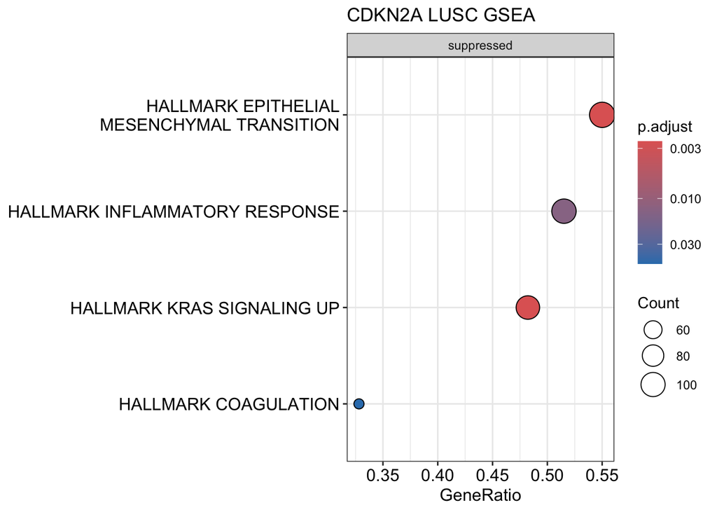

```r
#########################################################
# CDKN2A
#########################################################

set.seed(1234)

res_CDKN2A <- run_edger_deg(
  expr_mat = LUSC_mat_driv,
  meta = lusc_meta_driv,
  status_col = "CDKN2A_status"
)

gene_list_CDKN2A <- res_CDKN2A$logFC

names(gene_list_CDKN2A) <- res_CDKN2A$SYMBOL

gene_list_CDKN2A <- sort(gene_list_CDKN2A, decreasing = TRUE)

msig_res_hall_CDKN2A <- GSEA(
  geneList = gene_list_CDKN2A,
  TERM2GENE = m_hall_symbol,
  pvalueCutoff = 0.05,
  minGSSize = 10,
  maxGSSize = 500,
  nPerm = 10000,
  pAdjustMethod = "BH"
)

dotplot(
  msig_res_hall_CDKN2A,
  split = ".sign",
  title = "CDKN2A LUSC GSEA"
) +
  facet_grid(. ~ .sign)
```

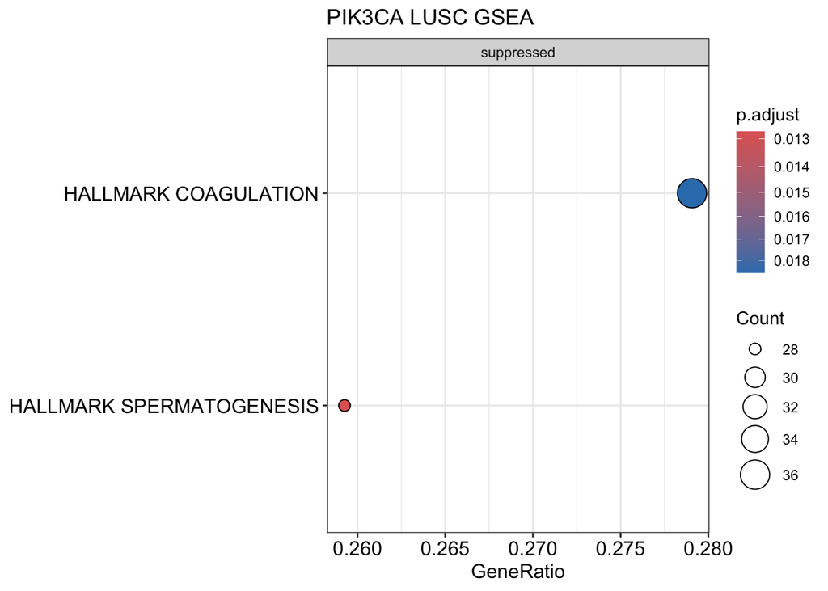

```r
#########################################################
# PIK3CA
#########################################################

set.seed(1234)

res_PIK3CA <- run_edger_deg(
  expr_mat = LUSC_mat_driv,
  meta = lusc_meta_driv,
  status_col = "PIK3CA_status"
)

gene_list_PIK3CA <- res_PIK3CA$logFC

names(gene_list_PIK3CA) <- res_PIK3CA$SYMBOL

gene_list_PIK3CA <- sort(gene_list_PIK3CA, decreasing = TRUE)

msig_res_hall_PIK3CA <- GSEA(
  geneList = gene_list_PIK3CA,
  TERM2GENE = m_hall_symbol,
  pvalueCutoff = 0.05,
  minGSSize = 10,
  maxGSSize = 500,
  nPerm = 10000,
  pAdjustMethod = "BH"
)

dotplot(
  msig_res_hall_PIK3CA,
  split = ".sign",
  title = "PIK3CA LUSC GSEA"
) +
  facet_grid(. ~ .sign)
```

# 10. Survival KMPlotter:

Para KMPlotter se ha obtado graficar para cada carcinoma el efecto de los top 5 genes up- y downregultaed de LUAD y LUSC, detectados por EdgeR y también por DESeq2, para aportar mayor rigurosidad. Aquellos genes qe se repiten en cada algoritmo se han tenido en cuenta como unica entrada, por lo tanto solo se verán los genes comunes y no comunes entre ambos algoritmos, además de los drivers estudiados anteriormente. Los top genes se han obtenido filtrando los genes por p.adj (FDR) < 0.05 y logFC <-1.5 (down) y logFC > 1.5 (Up), a partir de los conjuntos se han ordenado por logFC decreciente y seleccionado aquellos con mayor logFC en cada caso, de esta manera se asegura que los genes muestran perfiles de expresión muy diferenciados del estado normal del tejido siempre significativos.

```r
conflicts_prefer(base::union)
top_up_lusc_edge_5 <- results_edgeR_lusc %>%
  dplyr::filter(FDR < 0.05,logFC > 1.5) %>%
  dplyr::arrange(desc(logFC)) %>%
  dplyr::slice_head(n = 5) %>%
  dplyr::pull(SYMBOL)

top_down_lusc_edge_5 <- results_edgeR_lusc %>%
  dplyr::filter(FDR < 0.05,logFC < -1.5) %>%
  dplyr::arrange(logFC) %>%
  dplyr::slice_head(n = 5) %>%
  dplyr::pull(SYMBOL)

top_up_luad_edge_5 <- results_edgeR_luad %>%
  dplyr::filter(FDR < 0.05,logFC > 1.5) %>%
  dplyr::arrange(desc(logFC)) %>%
  dplyr::slice_head(n = 5) %>%
  dplyr::pull(SYMBOL)

top_down_luad_edge_5 <- results_edgeR_luad %>%
  dplyr::filter(FDR < 0.05,logFC < -1.5) %>%
  dplyr::arrange(logFC) %>%
  dplyr::slice_head(n = 5) %>%
  dplyr::pull(SYMBOL)



top_up_luad_des_5 <- results_deseq_luad %>%
  filter(padj < 0.05, log2FoldChange > 1.5) %>% arrange(desc(log2FoldChange)) %>%
  dplyr::slice_head(n = 5) %>%
  pull(SYMBOL)


top_down_luad_des_5 <- results_deseq_luad %>%
  filter(padj < 0.05, log2FoldChange < -1.5) %>%
  arrange(log2FoldChange) %>%
  dplyr::slice_head(n = 5)%>%
  pull(SYMBOL)


top_up_lusc_des_5 <- results_deseq_lusc %>%
  filter(padj < 0.05, log2FoldChange > 1.5) %>% arrange(desc(log2FoldChange)) %>%
  dplyr::slice_head(n = 5) %>%
  pull(SYMBOL)


top_down_lusc_des_5 <- results_deseq_lusc %>%
  filter(padj < 0.05, log2FoldChange < -1.5) %>% arrange(log2FoldChange) %>%
  dplyr::slice_head(n = 5) %>%
  pull(SYMBOL)

intersect(top_up_luad_edge_5, top_up_luad_des_5)
```

```
## [1] "TFF2"      "REG4"      "LINC00676"
```

```r
intersect(top_down_luad_edge_5, top_down_luad_des_5)
```

```
## [1] "SLC6A4"       "C10orf67-AS1" "AGER"         "CD300LG"      "FABP4"
```

```r
intersect(top_up_lusc_edge_5, top_up_lusc_des_5)
```

```
## [1] "CSN3"
```

```r
intersect(top_down_lusc_edge_5, top_down_lusc_des_5)
```

```
## [1] "ITLN1"     "SFTPC"     "LINC02016" "AGER"      "SLC6A4"
```

# 11. Analisis Comparativo LUAD tumoral vs LUSC tumoral

Se ha mantenido el DEG inicial que se había planteado en comparar muestras tumorales de LUSC vs LUAD:

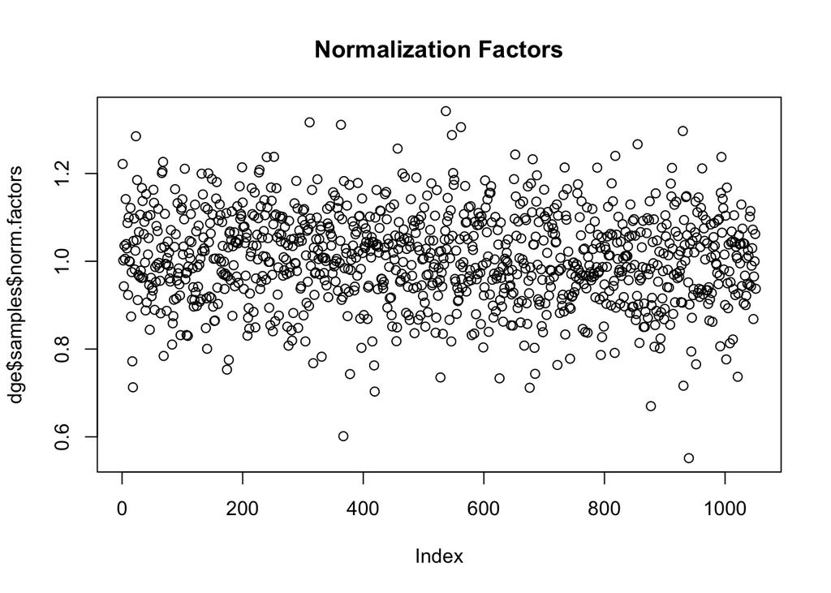

```r
library(edgeR)
library(EnhancedVolcano)
dge <- DGEList(counts = lung_mat, group = factor(lung_meta$cancer_type))
keep <- filterByExpr(dge)
dge1 <- dge[keep,,keep.lib.size=FALSE]

#Normalización TMM y comprobación:
dge <- normLibSizes(dge1,"TMM") # normalizción de datos por TMM

   ## Graficación de normalización:
plot(dge$samples$norm.factors, main="Normalization Factors")
```

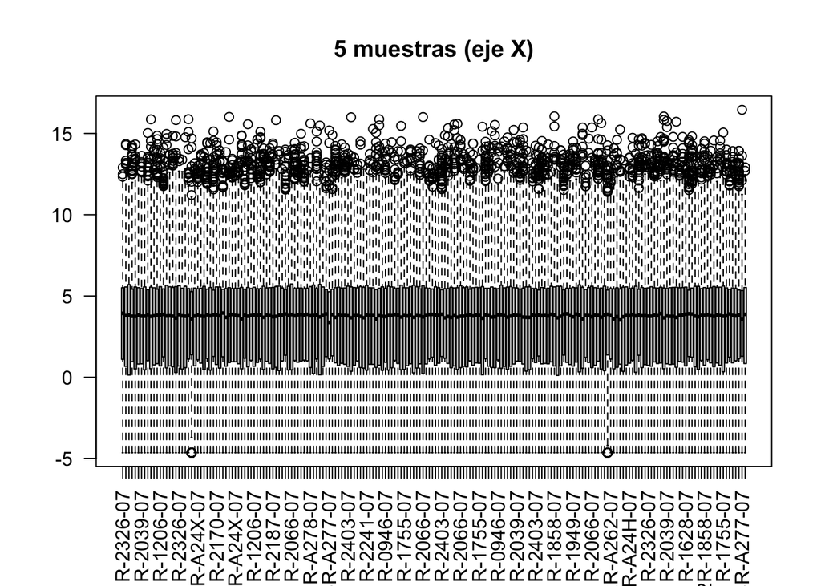

```r
boxplot(cpm(dge, log=TRUE)[, 1:200],
        las = 2,
        main = "5 muestras (eje X)")
```

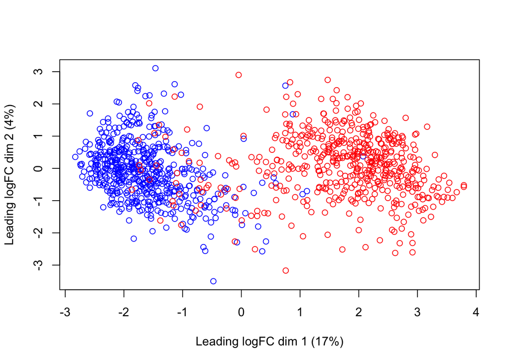

```r
conflicted::conflicts_prefer(base::as.factor)

col_er <- as.factor(dge$samples$group)
levels(col_er) <- c("blue","red")
col_er <- as.character(col_er)
plotMDS(cpm(dge, log=TRUE), labels=NULL, pch=1, col=col_er)
```

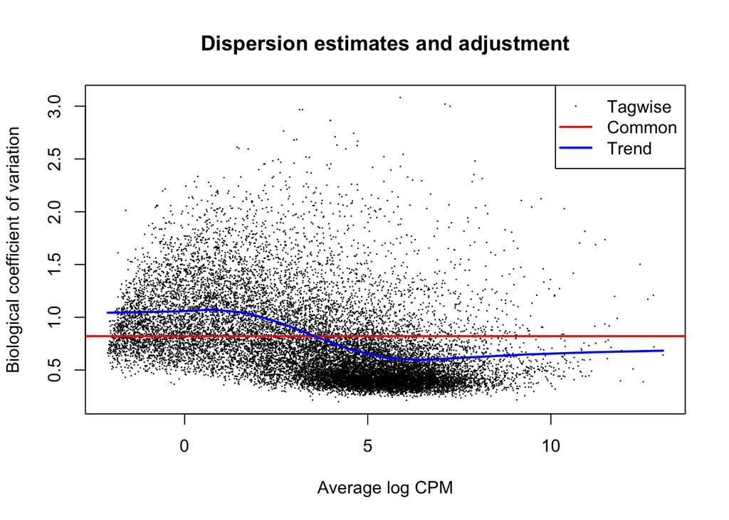

```r
group <- factor(dge$samples$group)
group <- relevel(group, ref="LUAD")
design <- model.matrix(~ group)

    ## Estimar dispersion:
dge <- estimateDisp(dge, design)
plotBCV(dge, main="Dispersion estimates and adjustment")
```

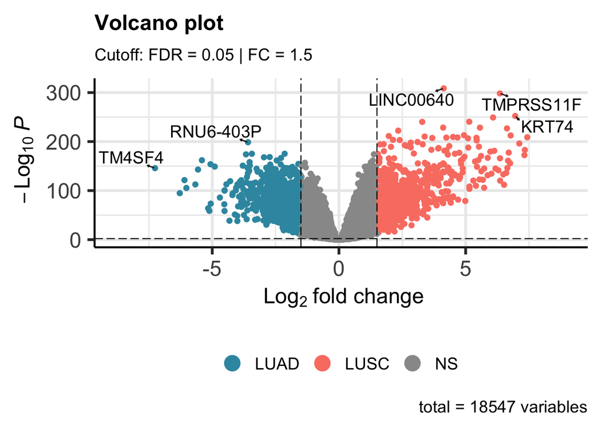

```r
    ## Ajustar modelo:
fit <- glmQLFit(dge, design)
qlf <- glmQLFTest(fit, coef = 2) # Compara LUSC vs LUAD
results_edgeR <- topTags(qlf, n = Inf)$table
results_edgeR <- results_edgeR %>%
  tibble::rownames_to_column("SYMBOL")

set.seed(1234)

#png("edgeRVolcano_LUAD_LUSC.png")
EnhancedVolcano(results_edgeR,
                lab = results_edgeR$SYMBOL,
                x = 'logFC',
                y = 'FDR',
                FCcutoff = 1.5,
                pCutoff = 0.01,
                colCustom = c(
                  "NS"   = "grey60",
                  "LUAD" = "#3697AF",
                  "LUSC" = "salmon")[results_edgeR %>%
                                       dplyr::mutate(group = dplyr::case_when(
                                         FDR <= 0.05 & logFC <= -1.5 ~ "LUAD",
                                         FDR <= 0.05 & logFC >= 1.5  ~ "LUSC",
                                         TRUE ~ "NS")) %>% dplyr::pull(group)],
                pointSize = 1,
                colAlpha = 1,
                drawConnectors = TRUE,
                widthConnectors = 0.5,
                legendPosition = 'bottom',
                subtitle = "Cutoff: FDR = 0.05 | FC = 1.5")
```

```r
#dev.off()
```

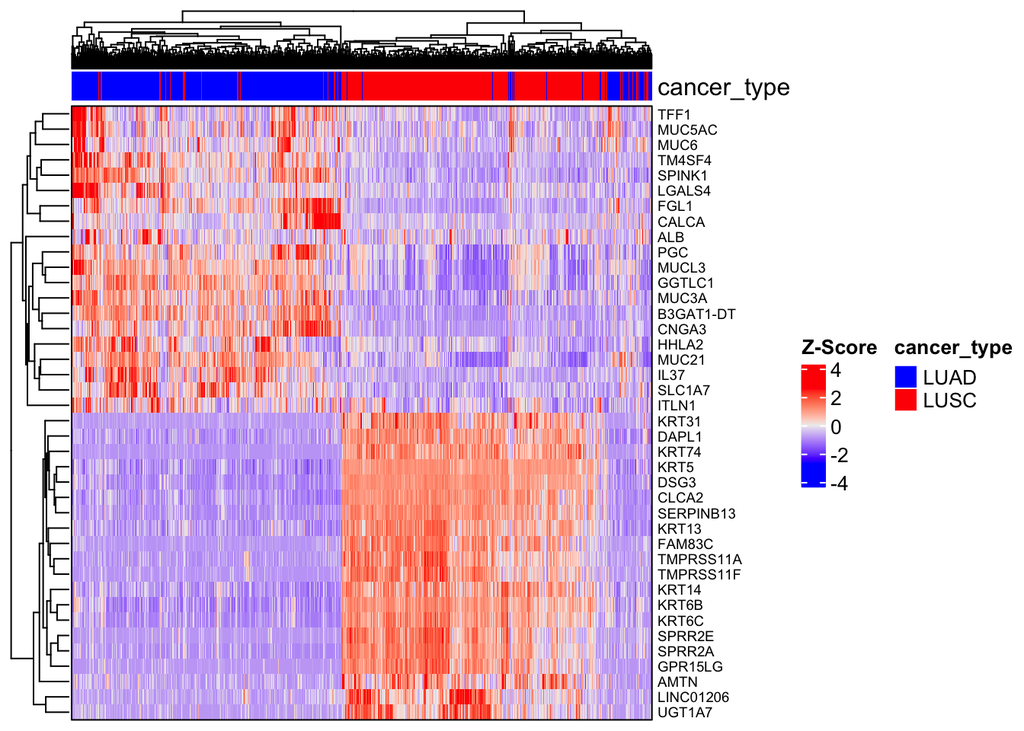

```r
top_LUSC <- results_edgeR %>%
  filter(logFC > 1.5) %>%
  arrange(desc(logFC)) %>%
  head(20)

top_LUAD <- results_edgeR %>%
  filter(logFC < -1.5) %>%
  arrange(logFC) %>%
  head(20)

selected_genes <- rbind(top_LUSC, top_LUAD)
top_40_genes <- selected_genes$SYMBOL

heatmap_matrix_edge <- cpm(dge, log=TRUE)[top_40_genes, ]
heatmap_matrix_edge <- t(scale(t(heatmap_matrix_edge)))

library(ComplexHeatmap)
set.seed(1234)

ha <- HeatmapAnnotation(
  cancer_type = lung_meta$cancer_type, col = list(cancer_type = c("LUSC" = "red", "LUAD" = "blue"))
)

Heatmap(heatmap_matrix_edge,
        name = "Z-Score",
        show_column_names = FALSE,
        border = TRUE,
        row_names_gp = gpar(fontsize = 7),
        top_annotation = ha)
```

# 12. COMPROBACIÓN DEG con DESEQ2:

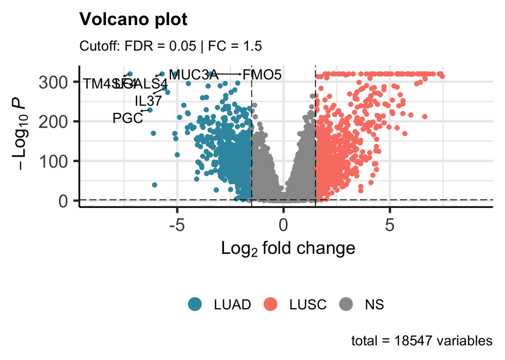

```r
library(DESeq2)


dds1 <- DESeqDataSetFromMatrix(
  countData = dge1$counts,
  colData = lung_meta,
  design = ~ cancer_type
)

dds <- DESeq(dds1, betaPrior = FALSE)
res <- results(dds, contrast = c("cancer_type", "LUSC", "LUAD"))
res_shrunk <- lfcShrink(dds,
  coef = "cancer_type_LUSC_vs_LUAD" ,
  type = "apeglm"
)
results_deseq <- as.data.frame(res_shrunk) %>%
  tibble::rownames_to_column("SYMBOL")%>%
  na.omit()

library(EnhancedVolcano)
set.seed(1234)


EnhancedVolcano(results_deseq,
                lab = results_deseq$SYMBOL,
                x = 'log2FoldChange',
                y = 'padj',
                FCcutoff = 1.5,
                pCutoff = 0.01,
                colCustom = c(
                  "NS"   = "grey60",
                  "LUAD" = "#3697AF",
                  "LUSC" = "salmon")[results_deseq %>%
                                       dplyr::mutate(group = dplyr::case_when(
                                         padj <= 0.05 & log2FoldChange <= -1.5 ~ "LUAD",
                                         padj <= 0.05 & log2FoldChange >= 1.5  ~ "LUSC",
                                         TRUE ~ "NS")) %>% dplyr::pull(group)],
                pointSize = 1,
                colAlpha = 1,
                drawConnectors = TRUE,
                widthConnectors = 0.5,
                legendPosition = 'bottom',
                subtitle = "Cutoff: FDR = 0.05 | FC = 1.5")
```

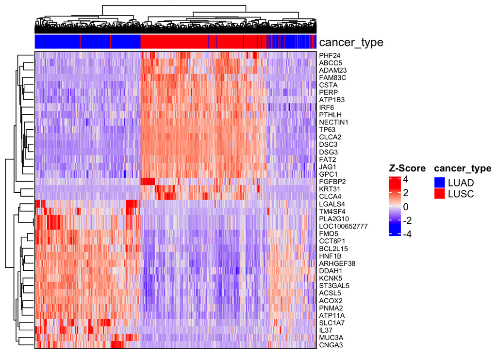

```r
top_LUSC_des <- results_deseq %>%
  filter(log2FoldChange > 1.5) %>%
  arrange(padj) %>%
  head(20)

top_LUAD_des <- results_deseq %>%
  filter(log2FoldChange < -1.5) %>%
  arrange(padj) %>%
  head(20)

selected_genes_des <- rbind(top_LUSC_des, top_LUAD_des)
top_40_genes_des <- selected_genes_des$SYMBOL

vsd_des <- vst(dds1, blind = TRUE)
vsd_des <- assay(vsd_des)
heatmap_matrix_des <- vsd_des[top_40_genes_des, ]
heatmap_matrix_des <- t(scale(t(heatmap_matrix_des)))

library(ComplexHeatmap)
set.seed(1234)

ha <- HeatmapAnnotation(
  cancer_type = lung_meta$cancer_type, col = list(cancer_type = c("LUSC" = "red", "LUAD" = "blue"))
)

Heatmap(heatmap_matrix_des,
        name = "Z-Score",
        show_column_names = FALSE,
        border = TRUE,
        row_names_gp = gpar(fontsize = 7),
        top_annotation = ha)
```

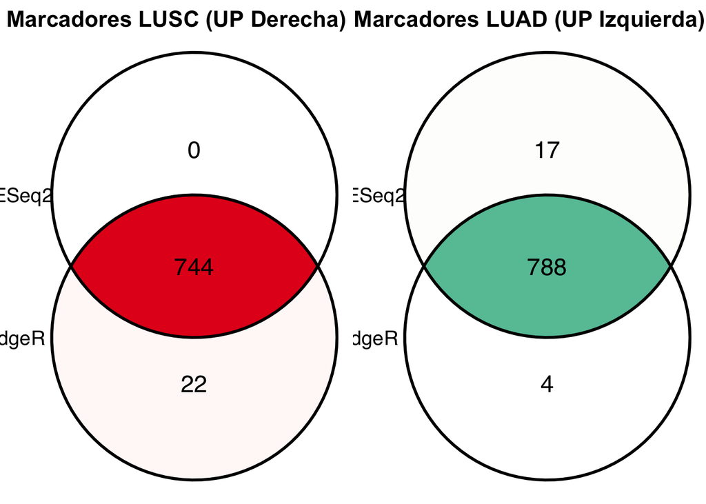

```r
# Instala y carga las librerías necesarias si no las tienes
# install.packages(c("ggVennDiagram", "ggplot2", "gridExtra", "RColorBrewer"))
library(ggVennDiagram)
library(ggplot2)
library(gridExtra)
library(RColorBrewer)

er_up_LUAD <- results_edgeR$SYMBOL[results_edgeR$FDR <= 0.05 & results_edgeR$logFC <= -1.5]
er_up_LUSC <- results_edgeR$SYMBOL[results_edgeR$FDR <= 0.05 & results_edgeR$logFC >= 1.5]
ds_up_LUAD <- results_deseq$SYMBOL[results_deseq$padj <= 0.05 & results_deseq$log2FoldChange <= -1.5]
ds_up_LUSC <- results_deseq$SYMBOL[results_deseq$padj <= 0.05 & results_deseq$log2FoldChange >= 1.5]

# 1. Preparar las listas de datos (asegúrate de que estas variables existen)
lista_lusc <- list(edgeR = er_up_LUSC, DESeq2 = ds_up_LUSC)
lista_luad <- list(edgeR = er_up_LUAD, DESeq2 = ds_up_LUAD)

# 2. Definir una paleta de colores elegante y profesional
# Usamos una paleta "Set1" de Brewer que es muy común en publicaciones
colores_lusc <- brewer.pal(3, "Set1")[1:2] # Rojo y Azul suaves
colores_luad <- brewer.pal(3, "Set2")[1:2] # Verde y Naranja suaves

# 3. Crear el primer diagrama (LUSC) con estética elíptica/diagonal
p1 <- ggVennDiagram(lista_lusc,
                    label = "count",        # Mostrar el número de genes
                    label_alpha = 0,        # Fondo de etiqueta transparente
                    label_size = 6,         # Tamaño del número central
                    category.names = c("edgeR", "DESeq2"), # Nombres de las categorías
                    set_size = 5) +         # Tamaño del texto de categoría
  scale_fill_gradient(low = "white", high = colores_lusc[1]) + # Degradado suave
  theme_void() +                           # Fondo totalmente limpio
  theme(legend.position = "none",          # Quitar la leyenda de colores
        plot.title = element_text(hjust = 0.5, size = 16, face = "bold")) +
  labs(title = "Marcadores LUSC (UP Derecha)")

# 4. Crear el segundo diagrama (LUAD) con la misma estética
p2 <- ggVennDiagram(lista_luad,
                    label = "count",
                    label_alpha = 0,
                    label_size = 6,
                    category.names = c("edgeR", "DESeq2"),
                    set_size = 5) +
  scale_fill_gradient(low = "white", high = colores_luad[1]) +
  theme_void() +
  theme(legend.position = "none",
        plot.title = element_text(hjust = 0.5, size = 16, face = "bold")) +
  labs(title = "Marcadores LUAD (UP Izquierda)")

# 5. PASO CLAVE: Dibujar ambos paneles juntos en diagonal
# Usamos grid.arrange para la disposición en panel
grid.arrange(p1, p2, ncol = 2)
```

Dados que los datos de ambos metodos han resultado ser muy similares se realizará un GSEA con los datos de edgeR:

# 13. Gene Set Enrichment Analysis (GSEA):

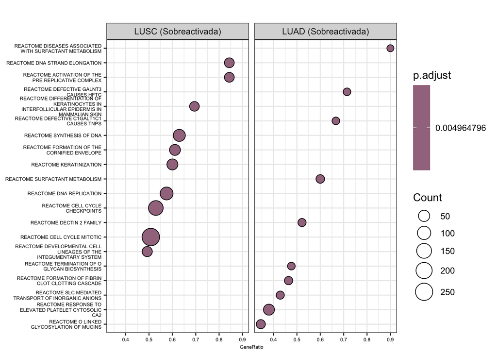

```r
library(clusterProfiler)
library(enrichplot)
library(ggplot2)
library(org.Hs.eg.db)

#Obtener ENTEREZID de los resultados de EdgeR:
df_edgeR <- results_edgeR
gene_map <- bitr(df_edgeR$SYMBOL,
                fromType = "SYMBOL",
                toType = "ENTREZID",
                OrgDb = org.Hs.eg.db)%>%
  distinct(SYMBOL, .keep_all = TRUE)

df_edgeR$ENTREZID <- gene_map$ENTREZID[match(df_edgeR$SYMBOL, gene_map$SYMBOL)]


#Extraer log2FoldChange:
gene_list_lfc <- df_edgeR$logFC

# Nombrar vector:
names(gene_list_lfc) <- df_edgeR$SYMBOL

#Evitar NA's:
gene_list <- na.omit(gene_list_lfc)

#Ordenar la lista de manera decreciente:
gene_list <- sort(gene_list, decreasing = TRUE)




# Realizar GSEA:

library(msigdbr)
m_t2g <- msigdbr(species = "Homo sapiens", category = "H") %>%
  select(gs_name, gene_symbol)
m_reactome_symbol <- msigdbr(species = "Homo sapiens",
                             category = "C2",
                             subcategory = "CP:REACTOME") %>%
  dplyr::select(gs_name, gene_symbol)

msig_gsea_reactome <- GSEA(geneList = gene_list,
                 TERM2GENE = m_reactome_symbol,
                 pvalueCutoff = 0.05,
                 seed = 2022,
                 minGSSize = 10,
                 maxGSSize = 800,
                 nPerm = 10000,
                 pAdjustMethod = "BH")


dotplot(msig_gsea_reactome, showCategory = 10, split = ".sign", font.size= 5) +
  facet_grid(. ~ .sign, labeller = as_labeller(c("activated" = "LUSC (Sobreactivada)",
                                      "suppressed" = "LUAD (Sobreactivada)")))
```

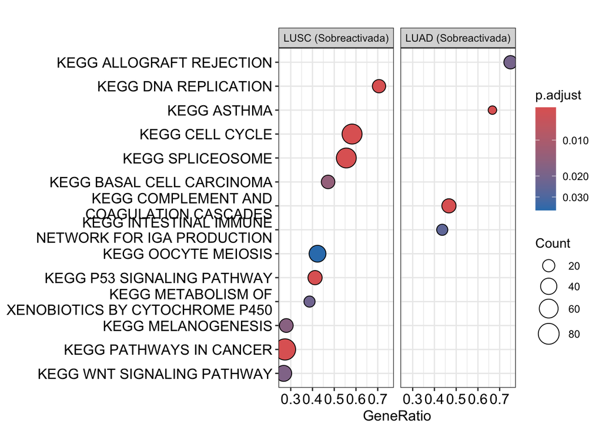

```r
##### KEGG #####
m_kegg_symbol <- msigdbr(species = "Homo sapiens",
                         category = "C2",
                         subcategory = "CP:KEGG_LEGACY") %>%
  dplyr::select(gs_name, gene_symbol)

msig_res <- GSEA(geneList = gene_list,
                 TERM2GENE = m_kegg_symbol,
                 pvalueCutoff = 0.05,
                 minGSSize = 10,
                 maxGSSize = 800,
                 nPerm = 10000,
                 pAdjustMethod = "BH")

require(DOSE)
dotplot(msig_res, showCategory = 10, split = ".sign") +
  facet_grid(. ~ .sign, labeller = as_labeller(c("activated" = "LUSC (Sobreactivada)",
                                      "suppressed" = "LUAD (Sobreactivada)")))
```

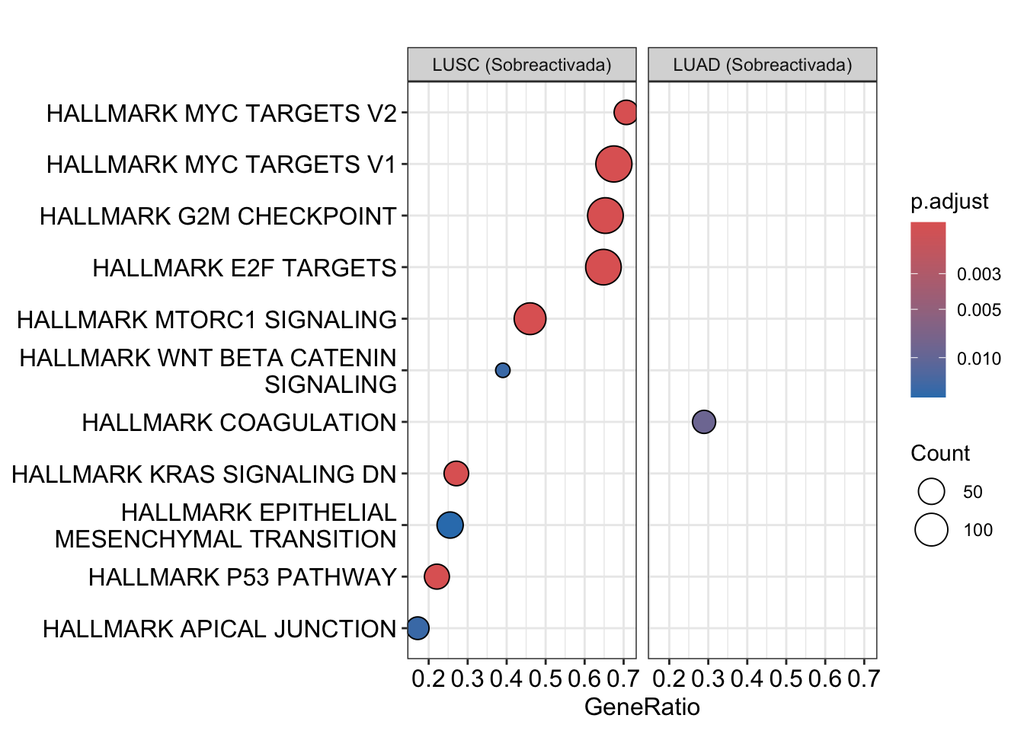

```r
###### HALLMARK####
m_hall_symbol <- msigdbr(species = "Homo sapiens",
                         category = "H") %>%
  dplyr::select(gs_name, gene_symbol)

msig_res_hall <- GSEA(geneList = gene_list,
                 TERM2GENE = m_hall_symbol,
                 pvalueCutoff = 0.05,
                 minGSSize = 10,
                 maxGSSize = 800,
                 nPerm = 10000,
                 pAdjustMethod = "BH")


dotplot(msig_res_hall, showCategory = 10, split = ".sign") +
  facet_grid(. ~ .sign, labeller = as_labeller(c("activated" = "LUSC (Sobreactivada)",
                                      "suppressed" = "LUAD (Sobreactivada)")))
```

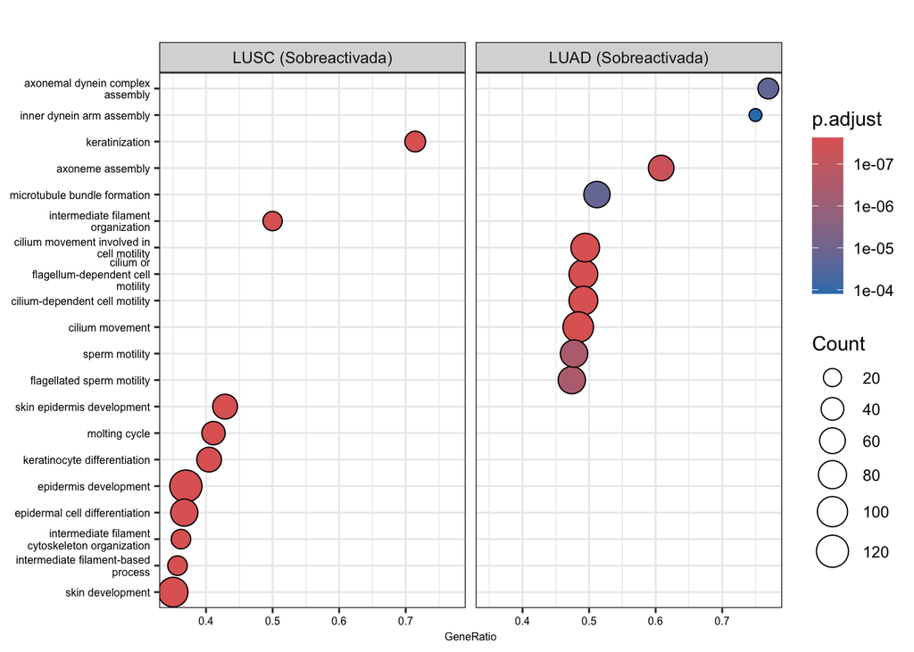

```r
## GO:

####### BP:
gse_GO_bp <- gseGO(geneList = gene_list,
                ont = "BP",
                OrgDb = org.Hs.eg.db,
                minGSSize = 10,
                maxGSSize = 800,
                keyType = "SYMBOL",
                pvalueCutoff = 0.05,
                pAdjustMethod = "BH")


dotplot(gse_GO_bp, split = ".sign",font.size= 6) +
  facet_grid(. ~ .sign,labeller = as_labeller(c("activated" = "LUSC (Sobreactivada)",
                                      "suppressed" = "LUAD (Sobreactivada)")))
```

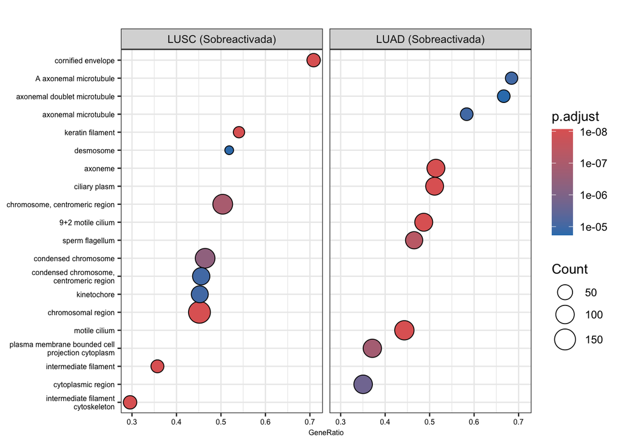

```r
###### CCs:
gse_GO_cc <- gseGO(geneList = gene_list,
                ont = "CC",
                OrgDb = org.Hs.eg.db,
                minGSSize = 10,
                maxGSSize = 800,
                keyType = "SYMBOL",
                pvalueCutoff = 0.05,
                pAdjustMethod = "BH")

dotplot(gse_GO_cc, split = ".sign",font.size= 6) +
  facet_grid(. ~ .sign, labeller = as_labeller(c("activated" = "LUSC (Sobreactivada)",
                                      "suppressed" = "LUAD (Sobreactivada)")))
```

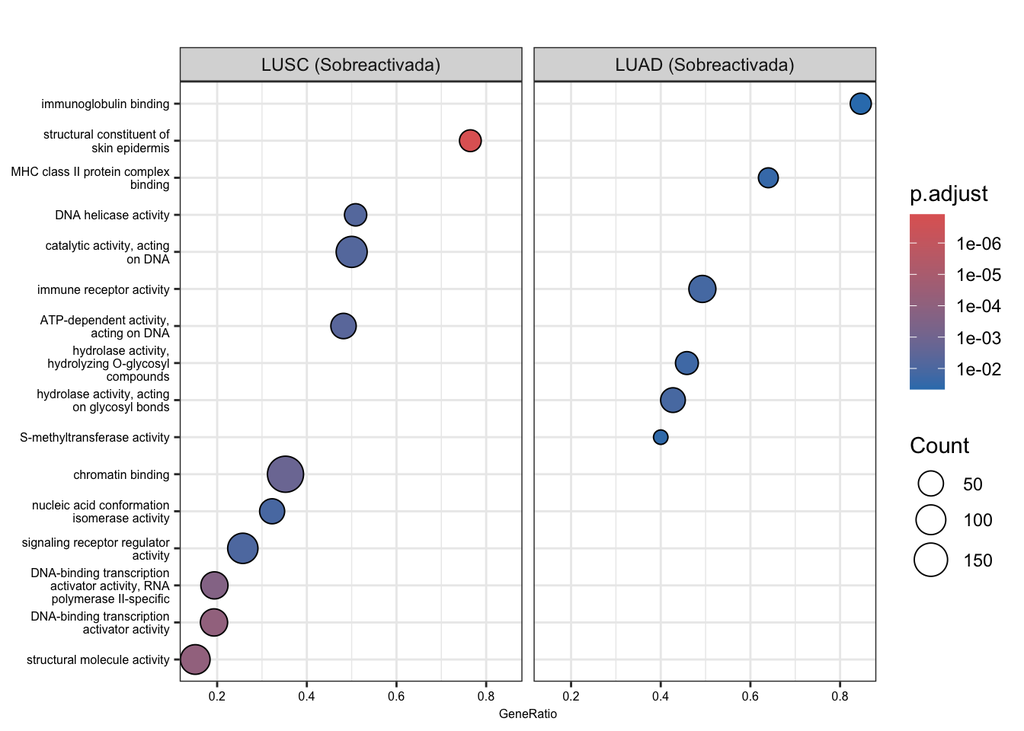

```r
##### MFs:
gse_GO_mf <- gseGO(geneList = gene_list,
                ont = "MF",
                OrgDb = org.Hs.eg.db,
                minGSSize = 10,
                maxGSSize = 800,
                keyType = "SYMBOL",
                pvalueCutoff = 0.05,
                pAdjustMethod = "BH")

dotplot(gse_GO_mf, split = ".sign",font.size= 6) +
  facet_grid(. ~ .sign, labeller = as_labeller(c("activated" = "LUSC (Sobreactivada)",
                                      "suppressed" = "LUAD (Sobreactivada)")))
```

Para realizar esto me he basado en el NES, positivos, enriquecido por genes en la parte superior de la tabla (upregulated en LUSC), NES negativo indica pathways enriquecidas por genes de la parte inferior de la tabla (downregulated en LUSC), pero en LUAD corresponde a pathways especificas del tumor.